# Electricity data with ggjoy

Matthew Butner

July 25, 2017

# ggjoy

ggjoy is a new package in R that visulizes stacked densitites. The package name comes from [Joy Division’s Unknown Pleasures album cover art](https://en.wikipedia.org/wiki/Unknown_Pleasures).

It integrates perfectly with the widely used visualization package for R, ggplot2, with the addition of the geom_joy() function.

# Electricity data

I will use ggjoy to look at the hourly wind generation and electricity prices within the Midcontinent Independent System Operator wholesale electricity market in the year 2014.

## by month of year

Here I show the density of wind generation and electricity price for the (roughly) seven hundred and twenty observations for each month.

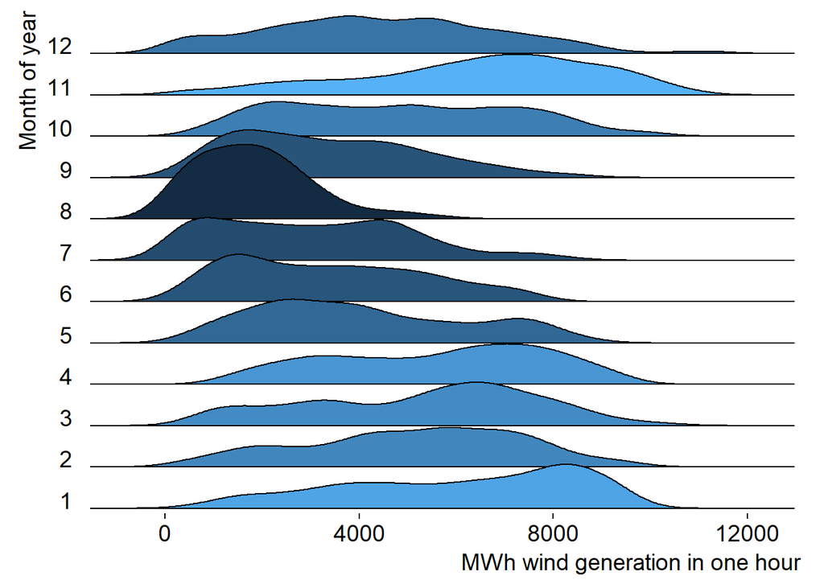

```r
hr_wind_2014 <- read_csv("data/miso/wind_gen/2014_clean.csv")
hr_wind_2014$month <- as.numeric(do.call(rbind,strsplit(hr_wind_2014$mkt_day,"/"))[,1])
hr_wind_2014$month_mean <- ave(hr_wind_2014$MWh, as.factor(hr_wind_2014$month))

ggplot(hr_wind_2014[order(hr_wind_2014$month),], aes(x=MWh, y=as.factor(month), fill=month_mean))+
  geom_joy2()+ theme_joy(grid = FALSE) +
  scale_x_continuous(expand = c(0.01, 0)) +
  scale_y_discrete(expand = c(0.01, 0))+
  labs(x="MWh wind generation in one hour", y="Month of year")+ guides(fill="none")
```

Seems like there wasn’t much wind generation in the late summer.

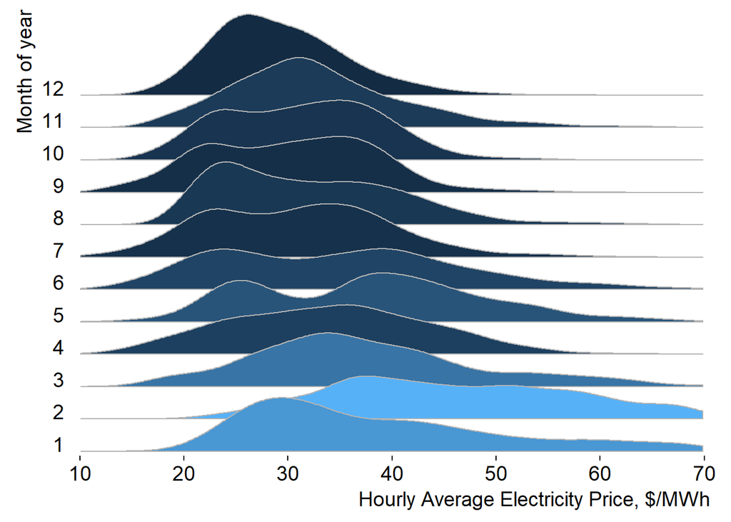

```r
hr_price_2014 <- read_csv("data/miso/da_lmp/2014_da_lmp_long.csv")
hr_price_2014$month <- as.numeric(substr(as.character(hr_price_2014$date),5,6))
hr_price_2014$month_mean <- ave(hr_price_2014$lmp, as.factor(hr_price_2014$month))

ggplot(hr_price_2014, aes(x=lmp, y=as.factor(month), fill=month_mean))+geom_joy2(col = "grey70",  scale = 2.5)+ theme_joy(grid = FALSE) +
  scale_x_continuous(expand = c(0.01, 0), limits=c(10,70)) +
  scale_y_discrete(expand = c(0.01, 0)) +
  labs(x="Hourly Average Electricity Price, $/MWh", y="Month of year")+guides(fill="none")
```

Electricity prices are declining over time?

# by hour of day

I can also look at intra-daily trends. This can say something about real time electricity pricing and renewable generation.

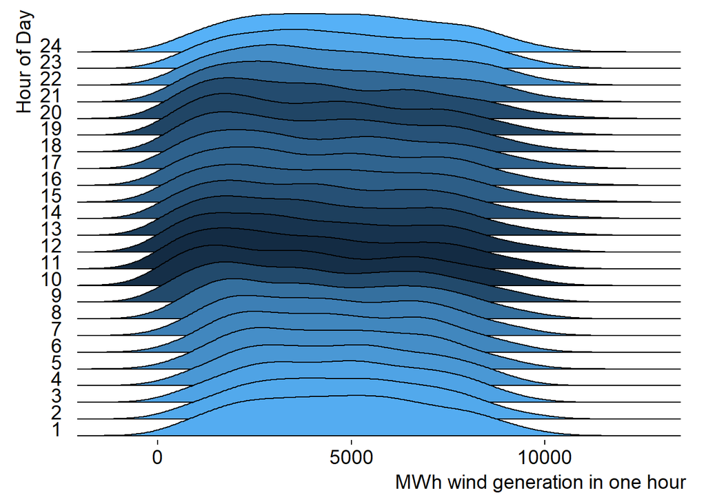

```r
hr_wind_2014 <- read_csv("data/miso/wind_gen/2014_clean.csv")
hr_wind_2014$hour_mean <- ave(hr_wind_2014$MWh, as.factor(hr_wind_2014$hour_end))
hr_wind_2014 <- hr_wind_2014[order(hr_wind_2014$hour_end),]

ggplot(hr_wind_2014, aes(x=MWh, y=as.factor(hour_end), fill=hour_mean, height=..density..))+
  geom_joy2(scale=2.5)+ theme_joy(grid = FALSE) +
  scale_x_continuous(expand = c(0.01, 0)) +
  scale_y_discrete(expand = c(0.01, 0))+
  labs(x="MWh wind generation in one hour", y="Hour of Day")+ guides(fill="none")
```

It looks like the 365 observations per hour have the same density across hours.

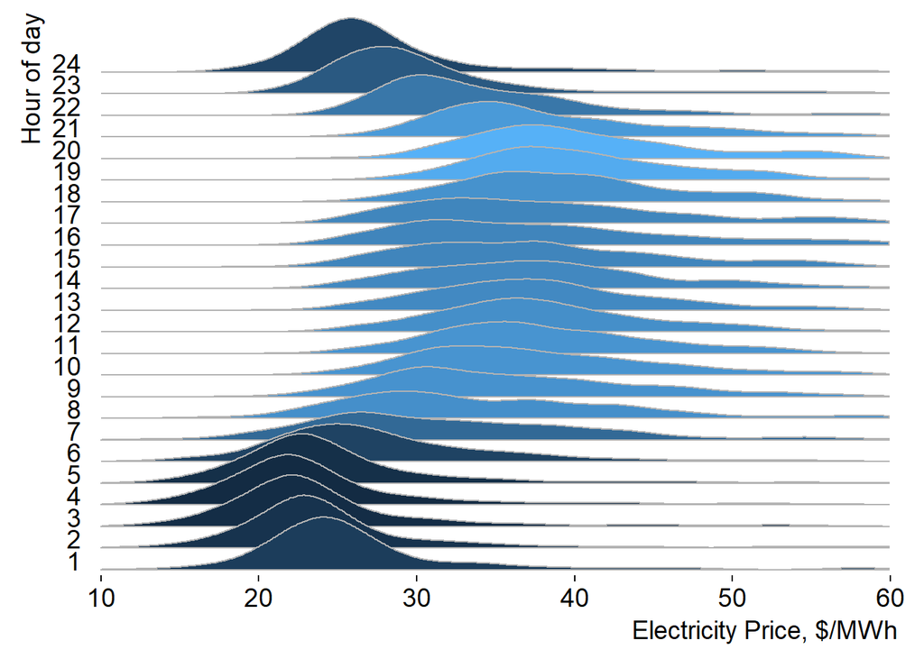

```r
hr_price_2014 <- read_csv("data/miso/da_lmp/2014_da_lmp_long.csv")
hr_price_2014$hour_mean <- ave(hr_price_2014$lmp, as.factor(hr_price_2014$hour))
hr_price_2014 <- hr_price_2014[order(-hr_price_2014$hour),]
ggplot(hr_price_2014, aes(x=lmp, y=as.factor(hour), fill=hour_mean))+geom_joy2(col = "grey70",  scale = 2.5)+ theme_joy(grid = FALSE) +
  scale_x_continuous(expand = c(0.01, 0), limits=c(10,60)) +
  scale_y_discrete(expand = c(0.01, 0)) +
  labs(x="Electricity Price, $/MWh", y="Hour of day")+guides(fill="none")
```

As expected, there are clear trends in electricity price within a day. This reflects patterns in demand for electricity.